# Lecture Script - Repeated Measures

Bioengineering Statistics (MA482/BE482)

```r
# This line should be the first line of code executed in your document. It
# ensures that additional functionality is available to you.
source("https://reyesem.github.io/files/MA482/MA482Setup.R")
```

This module contains code for modeling a quantitative response when the response is repeatedly measured on each subject. These models take one of two different forms, but the overall idea is the same — we need a model which accounts for the correlation among the errors introduced by repeatedly measuring a response on the same individual.

Keep in mind that while we are studying a different modeling technique, many of the modeling strategies introduced earlier in the course are still available to us.

## Importance of Study Design

It is rare that your data is not stored in a CSV file (which can again be created using any software program). It is generally best practice to save the data in such a file alongside another file that describes the variables in the dataset. However, when working with a small dataset, it is sometimes just as easy to enter the data directly into the program. While this is rare, we can use the `tibble()` function for doing so (a play on the word “table” since this function was already taken).

The most important thing to keep in mind when creating your own dataset is the importance of storing the data in a usable fashion. Each column should be a unique variable, and each row should be a single observation. It is common in the sciences to store two samples side-by-side in a spreadsheet. This is poor practice because it creates confusion about what is a single observation.

```r
# Enter small dataset
fat <- tibble(
  Subject = rep(c(1, 2, 3, 4, 5, 6), times = 4),
  Fat = c(44.5, 33.0, 19.1, 9.4, 71.3, 51.2,
          7.3, 21.0, 5.0, 4.6, 23.3, 38.0,
          3.4, 23.1, 11.8, 4.6, 25.6, 36.0,
          12.4, 25.4, 22.0, 5.8, 68.2, 52.6),
  PillType = rep(c("No Pill", "Tablet", "Capsule", "Coated"), each = 6)
)
```

A simple linear model would produce the following results.

```
# A tibble: 4 x 7
  term            estimate std.error statistic p.value conf.low conf.high
  <chr>              <dbl>     <dbl>     <dbl>   <dbl>    <dbl>     <dbl>
1 (Intercept)       17.4        7.74    2.25    0.0359     1.27      33.6
2 PillTypeCoated    13.7       10.9     1.25    0.227     -9.19      36.5
3 PillTypeNo Pill   20.7       10.9     1.89    0.0737    -2.17      43.5
4 PillTypeTablet    -0.883     10.9    -0.0807  0.937    -23.7       22.0
```

```
Linear hypothesis test

Hypothesis:
PillTypeCoated = 0
PillTypeNo Pill = 0
PillTypeTablet = 0

Model 1: restricted model
Model 2: Fat ~ PillType

  Res.Df    RSS Df Sum of Sq      F Pr(>F)
1     23 9202.0
2     20 7193.4  3    2008.6 1.8615 0.1687
```

A graphical summary of the data is given below.

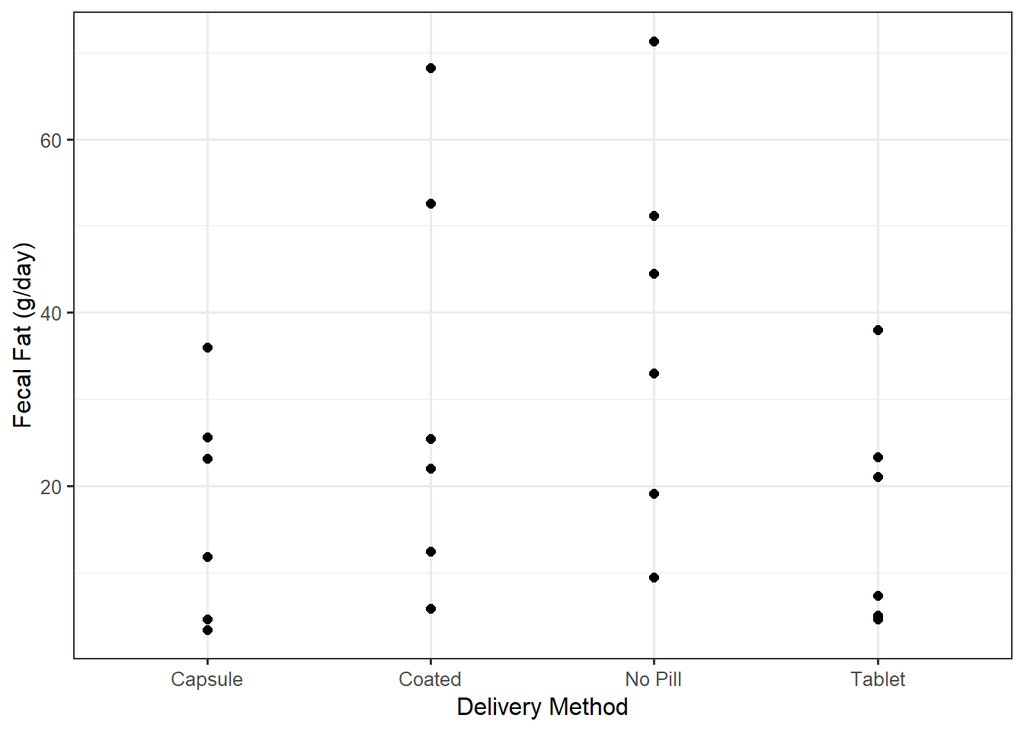

Sometimes, the structure of a dataset can tell you a lot about how things are described. Here is a snapshot of the data which accompanies the Greenhouse example.

```r
greenhouse <- read_csv("Greenhouse.csv")
```

```r
greenhouse
```

```
# A tibble: 36 x 4
   Yield Treatment   Pot Plant
   <dbl> <chr>     <dbl> <dbl>
 1  20.6 None          1     1
 2  22.3 None          1     2
 3  19.8 None          1     3
 4  23.4 None          2     1
 5  21.9 None          2     2
 6  22.8 None          2     3
 7  21.8 None          3     1
 8  20.6 None          3     2
 9  21.3 None          3     3
10  27.6 Straw         1     1
# ... with 26 more rows
```

## Mixed Effects Models

The correlation among the data should affect not only our modeling strategy but also how we graphically summarize the data. Here are a couple of ways that we might summarize the data. To my knowledge, there is not a commonly accepted “best practice” here. The key is to showcase the correlation structure.

There are two things about the code for this graphic worth pointing out. First, the subject identifer `Subject` was entered as a numeric variable. In order for color to not be a gradient, we want the subject to be treated as a categorical variable; so, we mutate the data to create a categorical variable. Next, in the graphic, we are not interesting in comparing subjects directly; they are a nuisance. So, I do not care about which color goes with which subject. So, I use the `guides(color = "none")` line to remove the legend for color. This type of plot can become overwhelming if we have thousands of subjects (not that many colors).

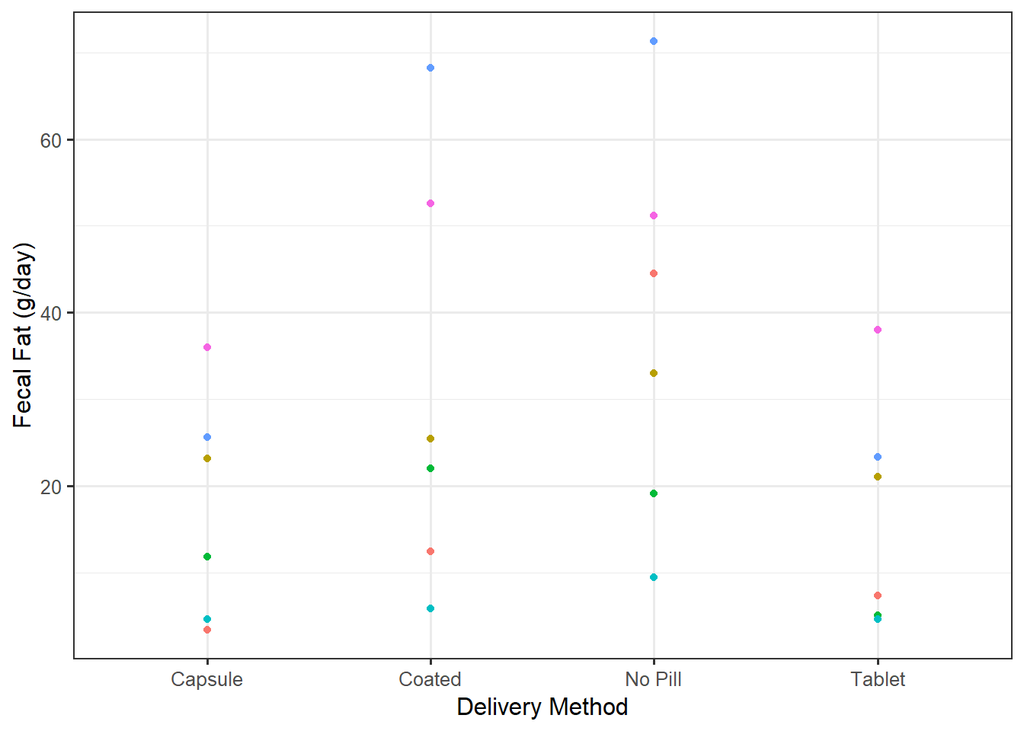

```r
fat <- fat %>%
  mutate(Subject = factor(Subject))

ggplot(data = fat,
       mapping = aes(y = Fat, x = PillType, color = Subject)) +
  geom_point() +
  labs(y = "Fecal Fat (g/day)",
       x = "Delivery Method",
       color = "") +
  guides(color = "none")
```

This graphic flips things around and places each subject on their own, more in the heirarchical framework we have discussed for the model. Then, it uses color to distinguish the treatment of interest. This can become overwhelming if we have thousands of subjects as the points become too close on the x-axis to tell how the groups are distinguishing themselves.

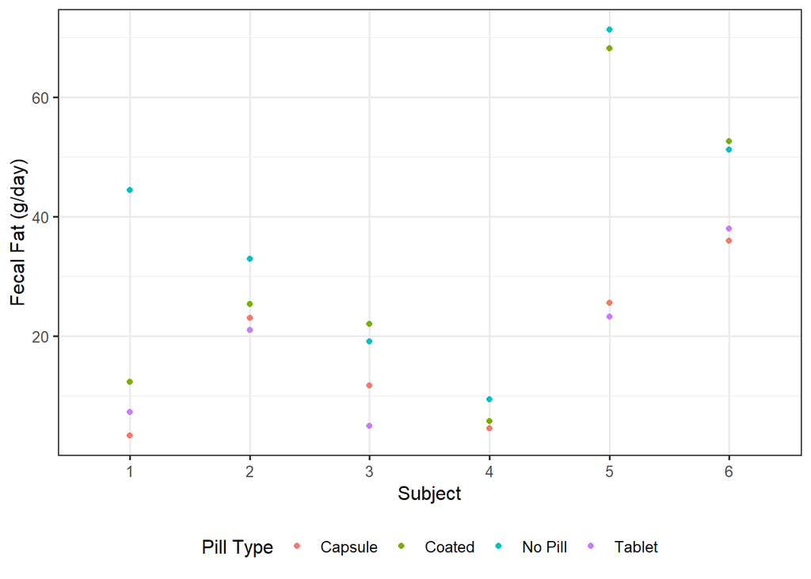

```r
ggplot(data = fat,
       mapping = aes(y = Fat, x = Subject, color = PillType)) +
  geom_point() +
  labs(y = "Fecal Fat (g/day)",
       x = "Subject",
       color = "Pill Type")
```

This graphic, which we will discuss even more in the next section, can be used with or without color to denote the groupings. The color may be dropped when you have many subjects. The lines help emphasize where the groups (individuals) are. In order to make the lines, you need to specify `group = Subject` in the mapping. Otherwise, it will try to draw lines within each subject *and* delivery method (which cannot be done successfully).

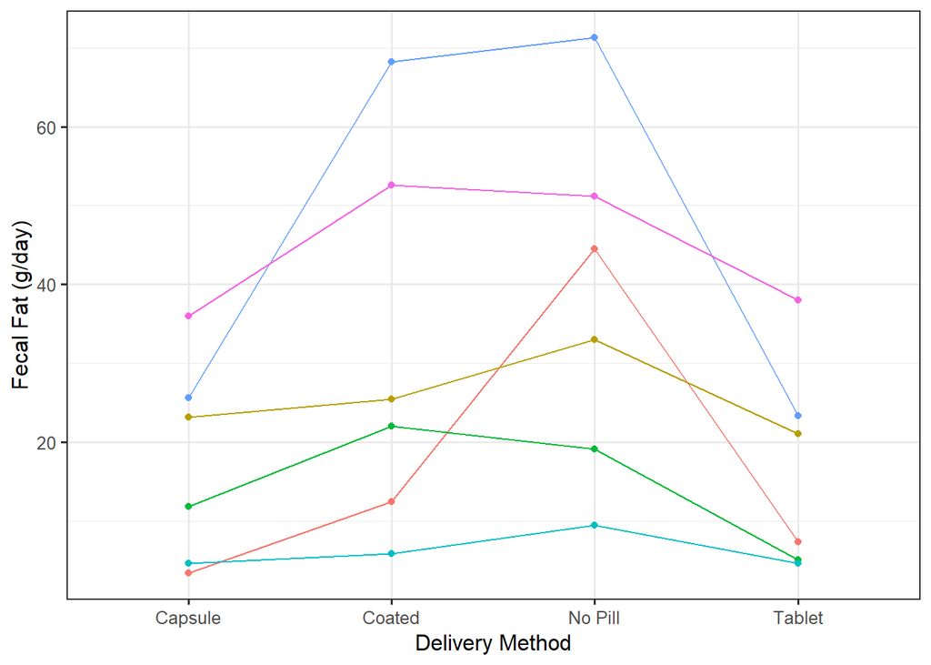

```r
ggplot(data = fat,
       mapping = aes(y = Fat, x = PillType, color = Subject, group = Subject)) +
  geom_point() +
  geom_line() +
  labs(y = "Fecal Fat (g/day)",
       x = "Delivery Method",
       color = "") +
  guides(color = "none")
```

In constructing the mixed effect model, we want to communicate the following model:

$$(\text{Fat})_{i,j} = \left(\beta_0 + b_{0,i}\right) + \beta_1(\text{Coated})_{i,j} +
\beta_2 (\text{No Pill})_{i,j} + \beta_3 (\text{Tablet})_{i,j} + \varepsilon_{i,j}$$

where $b_{0,i}$ is assumed to be IID from a $N\left(0, \sigma^2_0\right)$ distribution and $\varepsilon_{i,j}$ is assumed to be IID from a $N\left(0, \sigma^2\right)$ distribution. In order to fit this model, we use the `lmer()` function from a package devoted to fitting mixed effects models. Note: the documentation for these functions is terrible (the author wrote a book to accompany the code because it was so dense). There can be a big learning curve, but we will be using it in its simplicity.

The key is that fixed effects are specified as usual. So, here `PillType` is viewed as having all fixed effects. Random effects are specified in parentheses. You need to specify the term on which the random effect lives (the 1 indicates the intercept) and then use the vertical bar to specify the grouping term. Here, `Subject` denotes that the random effect changes with each subject in the data, which corresponds to the $i$ index on the $b_{0,i}$ term above.

```r
fat.mixed <- lmer(Fat ~ PillType + (1 | Subject), data=fat)
```

We can view the model as usual with the `tidy()` function. *Note: you may see a warning regarding the output which is just a result of how it is grabbing the output from the `lmer()` function and this can be ignored*.

```r
tidy(fat.mixed)
```

```
# A tibble: 6 x 5
  term                    estimate std.error statistic group
  <chr>                      <dbl>     <dbl>     <dbl> <chr>
1 (Intercept)               17.4        7.74     2.25  fixed
2 PillTypeCoated            13.6        5.97     2.29  fixed
3 PillTypeNo Pill           20.7        5.97     3.46  fixed
4 PillTypeTablet            -0.883      5.97    -0.148 fixed
5 sd_(Intercept).Subject    15.9       NA       NA     Subject
6 sd_Observation.Residual   10.3       NA       NA     Residual
```

Notice a couple of things about the output:

- In addition to the estimates for the fixed effects, we have estimates for the variability in the random effects. We have the standard deviation $\sigma_0$ which is estimated to be 15.896 and an estimate for the standard deviation of the error term $\sigma$ which is estimated to be 10.344.
- There are no p-values. It is unclear the “right” way to conduct hypothesis tests in mixed effects models. The only widely agreed upon rule is that with enough data, large sample theory kicks in. Bootstrapping may work, but it infitely more complex in a mixed model setting.

To implement the large-sample theory, we can use the `linearHypothesis()` function as before. Testing if there is a difference between any of the delivery methods is a test about the fixed effects.

```r
K <- matrix(
  c(0, 1, 0, 0,
    0, 0, 1, 0,
    0, 0, 0, 1),
  nrow = 3, ncol = 4, byrow = TRUE
)

linearHypothesis(fat.mixed, K)
```

```
Linear hypothesis test

Hypothesis:
PillTypeCoated = 0
PillTypeNo Pill = 0
PillTypeTablet = 0

Model 1: restricted model
Model 2: Fat ~ PillType + (1 | Subject)

  Df  Chisq Pr(>Chisq)
1
2  3 18.772  0.0003047 ***
---
Signif. codes:  0 '***' 0.001 '**' 0.01 '*' 0.05 '.' 0.1 ' ' 1
```

To obtain confidence intervals for the parameters of the model, we can use the `confint()` function. While `tidy()` can provide confidence intervals, it only uses large sample theory for the fixed effects. To get likelihood-based confidence intervals for the random effects as well, we need the `confint()` function.

```r
confint(fat.mixed, level = 0.95)
```

```
Computing profile confidence intervals ...
```

```
                     2.5 %   97.5 %
.sig01            8.108942 30.23380
.sigma            7.032965 13.62217
(Intercept)       1.861171 32.97216
PillTypeCoated    2.368434 24.93157
PillTypeNo Pill   9.385100 31.94823
PillTypeTablet  -12.164900 10.39823
```

For the dental example, we can visualize the data over time, again, showing the correlation by connecting the subjects. This is known as a *spaghetti plot*.

```r
dental <- read_csv("Dental.csv")
```

There is one additional complication in this graphic. The subject identifiers are not unique. That is, “1” is used to represent the first female subject as well as the first male subject. Again, this is generally poor practice, but you see it in different datasets. As a result, a subject is uniquely defined by both their subject number and their gender. This new variable can be constructed using the `interaction()` function which creates a new variable by splicing them together (it does not create an interaction like in a model). I also change the color palette because I got tired of “Easter egg” colors.

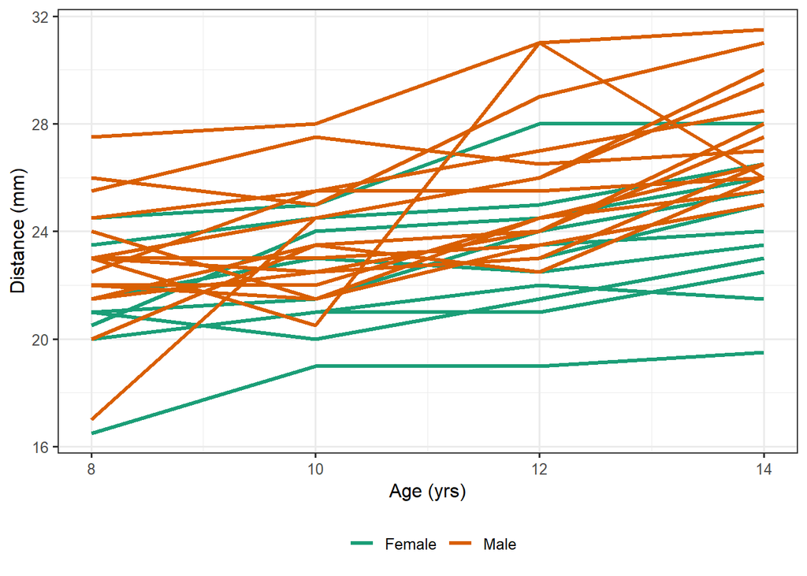

```r
# spaghetti plot connects each subject.
ggplot(data = dental,
       mapping = aes(y = Distance, x = Age, color = Gender,
                     group = interaction(Subject, Gender))) +
  geom_line(size = 1.2) +
  labs(y = "Distance (mm)",
       x = "Age (yrs)",
       color = "") +
  scale_color_brewer(type = "qual", palette = "Dark2")
```

The model suggested for this process has the form

$$(\text{Distance})_i = \left(\beta_0 + b_{0,i}\right) + \beta_2 (\text{Male})_i + \left(\beta_1 + b_{1,i}\right) (\text{Age})_{i,j} + \varepsilon_{i,j}$$

```r
dental <- dental %>%
  mutate(NewSubject = interaction(Subject, Gender))

fit.dental <- lmer(Distance ~ 1 + Gender + Age + (1 + Age | NewSubject),
                   data = dental)

tidy(fit.dental, conf.int = TRUE)
```

```
# A tibble: 7 x 7
  term              estimate std.error statistic conf.low conf.high group
  <chr>                <dbl>     <dbl>     <dbl>    <dbl>     <dbl> <chr>
1 (Intercept)         15.5      0.944      16.4    13.6      17.3   fixed
2 GenderMale           2.15     0.757       2.83    0.661     3.63  fixed
3 Age                  0.660    0.0712      9.27    0.521     0.800 fixed
4 sd_(Intercept).N~    2.80    NA          NA      NA        NA     NewSub~
5 sd_Age.NewSubject    0.226   NA          NA      NA        NA     NewSub~
6 cor_(Intercept).~   -0.766   NA          NA      NA        NA     NewSub~
7 sd_Observation.R~    1.31    NA          NA      NA        NA     Residu~
```

## Longitudinal Data Analysis and Generalized Estimating Equations

Just as a reminder of the data we are working with, here is a graphical representation of how the distance between two points in the jaw changes in children as they grow.

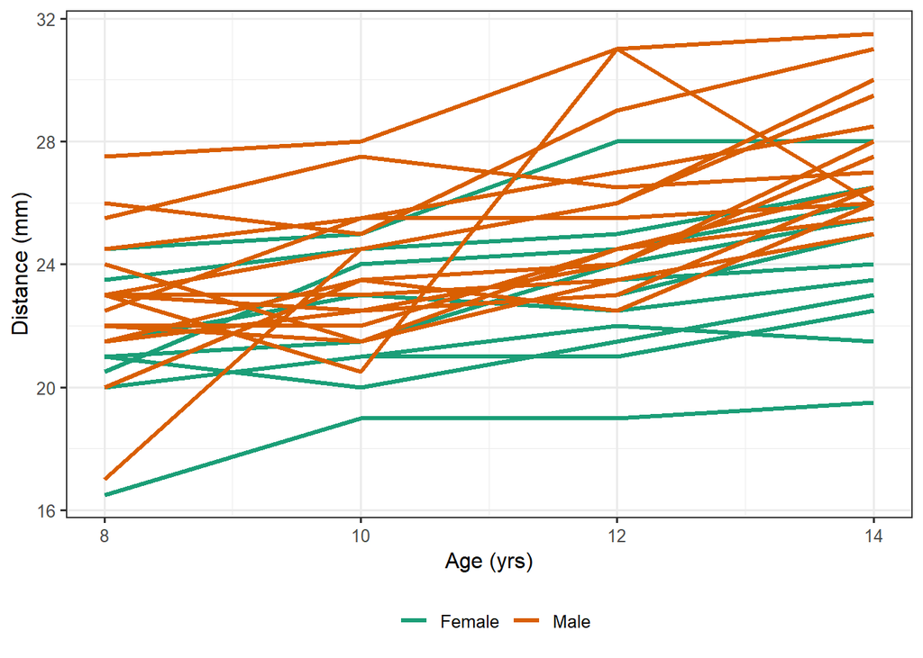

Generalized estimating equations (which rely on the robust variance-covariance matrix) are used to fit the proposed linear model using the `geeglm()` function. The primary information provided to the function is very similar to the `lm()` function for fitting linear models. The additional options that need to be specified are

- `id =`, which specifies the subject/grouping identifier. **IMPORTANT: the data must be sorted (“arranged”) in the order of the subject prior to passing the data to `geeglm()`. This is done with the `arrange()` function.**
- `corstr =`, defines the working correlation struction. Options include:
  - `"independence"` which defines an indepedence working correlation structure. This can be used to adjust for non-constant variance in a typical linear model.
  - `"exchangeable"` which signifies a compound symmetric or exchangeable working correlation matrix.
  - `"ar1"` which defines the autoregressive correlation structure.
  - `"unstructured"` which defines an unstructured matrix.

```r
# order data by subject
# accounted for potential that subject is defined uniquely within gender
dental <- dental %>%
  arrange(Gender, Subject)

# construct fit
fit.gee.dental <- geeglm(Distance ~ Age + Gender + Age:Gender, data = dental,
                         id = Subject, corstr = "exchangeable")

tidy(fit.gee.dental)
```

```
# A tibble: 4 x 5
  term           estimate std.error statistic  p.value
  <chr>             <dbl>     <dbl>     <dbl>    <dbl>
1 (Intercept)      17.4      0.725    574.    0.
2 Age               0.480    0.0631    57.7   3.05e-14
3 GenderMale       -1.03     1.38       0.561 4.54e- 1
4 Age:GenderMale    0.305    0.117      6.80  9.10e- 3
```

```r
glance(fit.gee.dental)
```

```
    n    sigma df.residual n.clusters max.cluster.size
1 108 2.214759         104         27                4
```

```r
# use independence working correlation structure
fit2.gee.dental <- geeglm(Distance ~ Age + Gender + Age:Gender, data = dental,
                          id = Subject, corstr = "independence")

tidy(fit2.gee.dental)
```

```
# A tibble: 4 x 5
  term           estimate std.error statistic  p.value
  <chr>             <dbl>     <dbl>     <dbl>    <dbl>
1 (Intercept)      17.4      0.725    574.    0.
2 Age               0.480    0.0631    57.7   3.05e-14
3 GenderMale       -1.03     1.38       0.561 4.54e- 1
4 Age:GenderMale    0.305    0.117      6.80  9.10e- 3
```

```r
glance(fit2.gee.dental)
```

```
    n    sigma df.residual n.clusters max.cluster.size
1 108 2.214759         104         27                4
```

```r
# use autoregressive structure
fit3.gee.dental <- geeglm(Distance ~ Age + Gender + Age:Gender, data = dental,
                          id = Subject, corstr = "ar1")

tidy(fit3.gee.dental)
```

```
# A tibble: 4 x 5
  term           estimate std.error statistic  p.value
  <chr>             <dbl>     <dbl>     <dbl>    <dbl>
1 (Intercept)      17.3      0.792    478.    0.
2 Age               0.484    0.0631    59.0   1.60e-14
3 GenderMale       -0.659    1.53       0.186 6.66e- 1
4 Age:GenderMale    0.283    0.124      5.22  2.24e- 2
```

```r
glance(fit3.gee.dental)
```

```
    n    sigma df.residual n.clusters max.cluster.size
1 108 2.217037         104         27                4
```

Notice that in the above, due to the robust variance-covariance matrix, the differences when changing the correlation structure are negligible. The estimates only change slightly with the AR(1) structure. In general, the estimates will remain unchanged. The p-values change only slightly. You should note that no one would present three different methods for analyzing a single question like this. We do this here only to illustrate the power of the robust variance-covariance matrix.

Using our initial fit (with the exchangeable working correlation matrix), we consider testing if the average distance differs for males and females at age 11.

```r
K.dental <- matrix(
  c(0, 0, 1, 11),
  nrow = 1, ncol = 4, byrow = TRUE
)

linearHypothesis(fit.gee.dental, K.dental)
```

```
Linear hypothesis test

Hypothesis:
GenderMale  + 11 Age:GenderMale = 0

Model 1: restricted model
Model 2: Distance ~ Age + Gender + Age:Gender

  Res.Df Df Chisq Pr(>Chisq)
1    105
2    104  1 9.583   0.001964 **
---
Signif. codes:  0 '***' 0.001 '**' 0.01 '*' 0.05 '.' 0.1 ' ' 1
```

This shows that there is evidence against the null hypothesis. However, in this case we would also like to estimate this difference. We can do that with the `confint()` function. *Note: this is accomplished with a special method written for this course and is not available by default.*

The `coef()` and `vcov()` functions are used to extract the coefficients and variance-covariance matrix of the coefficients from the model, respectively.

```r
confint(K.dental, coef. = coef(fit.gee.dental), vcov. = vcov(fit.gee.dental))
```

```
        2.5     97.5
1 0.8514994 3.790546
```

Just for kicks and giggles, think about the following model

$$(\text{Distance})_i = \beta_0 + \beta_1(\text{Age} - \text{Avg Age})_i + \beta_2 (\text{Male})_i + \beta_3 (\text{Age} - \text{Avg Age})_i (\text{Male})_i + \varepsilon_i$$

where $(\text{Male})_i$ is an indicator for the male gender. Then, notice that $\beta_0$ is the average response for an average aged female. And then the test for $\beta_2$ is the test of whether males and females differ for children of the same average age. Notice that the confidence interval for the effect of Gender is the same as that obtained above using a the general linear hypothesis testing framework; this is because the average age across the sample is 11.

```r
dental <- dental %>%
  mutate(CenteredAge = Age - mean(Age))

fit4.gee.dental <- geeglm(Distance ~ CenteredAge + Gender + CenteredAge:Gender,
                          data = dental, id = Subject, corstr = "exchangeable")

tidy(fit4.gee.dental, conf.int = TRUE)
```

```
# A tibble: 4 x 7
  term             estimate std.error statistic  p.value conf.low conf.high
  <chr>               <dbl>     <dbl>     <dbl>    <dbl>    <dbl>     <dbl>
1 (Intercept)        22.6      0.605    1401.   0.        21.5       23.8
2 CenteredAge         0.480    0.0631     57.7  3.05e-14   0.356      0.603
3 GenderMale          2.32     0.750       9.58 1.96e- 3   0.851      3.79
4 CenteredAge:Gen~    0.305    0.117       6.80 9.10e- 3   0.0758     0.534
```

We now return to the greenhouse study to illustrate that generalized estimating equations can be used to fit a repeated measures model that is not strictly longitudinal in nature. We note that the variable `Pot` does not uniquely define a unit of randomization in this dataset; that is, pot 1 under one treatment is not the same as pot 1 under a different treatment. We again use `interaction()` in order to create a unique subject identifier.

```r
greenhouse <- greenhouse %>%
  mutate(Pot = interaction(Treatment, Pot))
```

Graphically, we can use color to distinguish different subsamples from the same pot. We use the `jitter()` view to eliminate the overplotting since many responses are similar. However, we do not want to jitter the points vertically (`height = 0`) but only left to right a slight amount (`width = 0.25`).

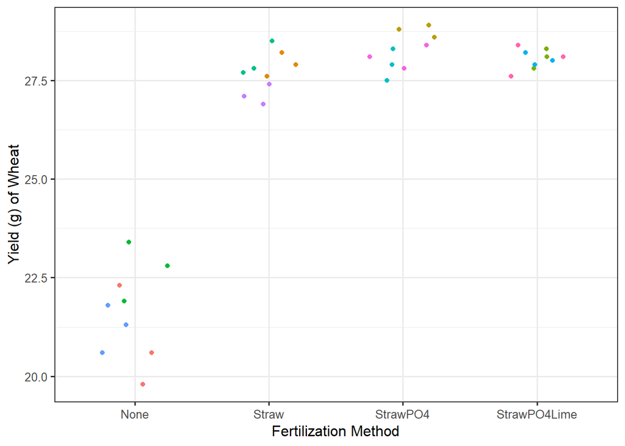

```r
ggplot(data = greenhouse,
       mapping = aes(y = Yield, x = Treatment, color = Pot)) +
  geom_jitter(width = 0.25, height = 0) +
  labs(y = "Yield (g) of Wheat",
       x = "Fertilization Method",
       color = "") +
  guides(color = "none")
```

The graphic alone suggests overwhelming evidence that the fertilizers result in an increase yield for wheat. We can fit the following model. We take care to remember to sort the data by the subject identifier first.

```r
greenhouse <- greenhouse %>%
  arrange(Pot)

fit.greenhouse <- geeglm(Yield ~ Treatment, data = greenhouse,
                         id = Pot, corstr = "exchangeable")

tidy(fit.greenhouse)
```

```
# A tibble: 4 x 5
  term                  estimate std.error statistic p.value
  <chr>                    <dbl>     <dbl>     <dbl>   <dbl>
1 (Intercept)              21.6      0.451     2292.       0
2 TreatmentStraw            6.07     0.504      145.       0
3 TreatmentStrawPO4         6.64     0.500      177.       0
4 TreatmentStrawPO4Lime     6.43     0.452      203.       0
```

```r
K.greenhouse <- matrix(
  c(0, 1, -1, 0,
    0, 0, 1, -1),
  nrow = 2, ncol = 4, byrow = TRUE
)

linearHypothesis(fit.greenhouse, K.greenhouse)
```

```
Linear hypothesis test

Hypothesis:
TreatmentStraw - TreatmentStrawPO4 = 0
TreatmentStrawPO4 - TreatmentStrawPO4Lime = 0

Model 1: restricted model
Model 2: Yield ~ Treatment

  Res.Df Df  Chisq Pr(>Chisq)
1     34
2     32  2 3.6644     0.1601
```